# Análisis Estadístico y ML del Titanic

## 6c. Feature Scaling

Feature scaling is an important concept of machine learning models. Often times a dataset contain features highly varying in magnitude and unit. For some machine learning models, it is not a problem. However, for many other ones, its quite a problem. Many machine learning algorithms uses euclidian distances to calculate the distance between two points, it is quite a problem. Let’s again look at a the sample of the **train** dataset below.

```julia
sample = shuffle(1:DF.nrow(X_train))[1:5]
X_train[sample, :]
```

5×37 DataFrame

| Row | Sex Float64 | Age Float64? | SibSp Float64 | Parch Float64 | is_alone Float64 | calculated_fare Float64 | title_Mr Float64 | title_Mrs Float64 | title_Miss Float64 | title_Master Float64 | title_rare Float64 | Pclass_3 Float64 | Pclass_1 Float64 | Pclass_2 Float64 | Cabin_G Float64 | Cabin_C Float64 | Cabin_E Float64 | Cabin_F Float64 | Cabin_T Float64 | Cabin_D Float64 | Cabin_A Float64 | Cabin_B Float64 | Embarked_S Float64 | Embarked_C Float64 | Embarked_Q Float64 | nLength_group_medium Float64 | nLength_group_long Float64 | nLength_group_good Float64 | nLength_group_short Float64 | … |
| --- | --- | --- | --- | --- | --- | --- | --- | --- | --- | --- | --- | --- | --- | --- | --- | --- | --- | --- | --- | --- | --- | --- | --- | --- | --- | --- | --- | --- | --- | --- |
| 1 | 1.0 | 44.0 | 0.0 | 0.0 | 1.0 | 8.05 | 1.0 | 0.0 | 0.0 | 0.0 | 0.0 | 1.0 | 0.0 | 0.0 | 1.0 | 0.0 | 0.0 | 0.0 | 0.0 | 0.0 | 0.0 | 0.0 | 1.0 | 0.0 | 0.0 | 1.0 | 0.0 | 0.0 | 0.0 | … |
| 2 | 0.0 | 6.0 | 0.0 | 1.0 | 0.0 | 16.5 | 0.0 | 0.0 | 1.0 | 0.0 | 0.0 | 0.0 | 0.0 | 1.0 | 0.0 | 0.0 | 0.0 | 0.0 | 1.0 | 0.0 | 0.0 | 0.0 | 1.0 | 0.0 | 0.0 | 1.0 | 0.0 | 0.0 | 0.0 | … |
| 3 | 1.0 | 9.0 | 0.0 | 2.0 | 0.0 | 6.84167 | 0.0 | 0.0 | 0.0 | 1.0 | 0.0 | 1.0 | 0.0 | 0.0 | 0.0 | 0.0 | 0.0 | 1.0 | 0.0 | 0.0 | 0.0 | 0.0 | 1.0 | 0.0 | 0.0 | 0.0 | 1.0 | 0.0 | 0.0 | … |
| 4 | 1.0 | 40.0 | 0.0 | 0.0 | 1.0 | 7.8958 | 1.0 | 0.0 | 0.0 | 0.0 | 0.0 | 1.0 | 0.0 | 0.0 | 1.0 | 0.0 | 0.0 | 0.0 | 0.0 | 0.0 | 0.0 | 0.0 | 1.0 | 0.0 | 0.0 | 0.0 | 0.0 | 0.0 | 1.0 | … |
| 5 | 1.0 | 28.0 | 0.0 | 0.0 | 1.0 | 13.5 | 1.0 | 0.0 | 0.0 | 0.0 | 0.0 | 0.0 | 0.0 | 1.0 | 1.0 | 0.0 | 0.0 | 0.0 | 0.0 | 0.0 | 0.0 | 0.0 | 1.0 | 0.0 | 0.0 | 1.0 | 0.0 | 0.0 | 0.0 | … |

Here **Age** and **Calculated_fare** is much higher in magnitude compared to others machine learning features. This can create problems as many machine learning models will get confused thinking **Age** and **Calculated_fare** have higher weight than other features. Therefore, we need to do feature scaling to get a better result. There are multiple ways to do feature scaling.

- **MinMaxScaler**-Scales the data using the max and min values so that it fits between 0 and 1.
- **StandardScaler**-Scales the data so that it has mean 0 and variance of 1.
- **RobustScaler**-Scales the data similary to Standard Scaler, but makes use of the median and scales using the interquertile range so as to aviod issues with large outliers.

I will discuss more on that in a different kernel. For now we will use **Standard Scaler** to feature scale our dataset.

### Before Scaling

```julia
print(DF.names(X_train))
DF.first(X_train, 5)
```

```
["Sex", "Age", "SibSp", "Parch", "is_alone", "calculated_fare", "title_Mr", "title_Mrs", "title_Miss", "title_Master"  …  "nLength_group_good", "nLength_group_short", "family_group_small", "family_group_loner", "family_group_large", "fare_group_Very_low", "fare_group_high", "fare_group_low", "fare_g…
```

5×37 DataFrame

| Row | Sex Float64 | Age Float64? | SibSp Float64 | Parch Float64 | is_alone Float64 | calculated_fare Float64 | title_Mr Float64 | title_Mrs Float64 | title_Miss Float64 | title_Master Float64 | title_rare Float64 | Pclass_3 Float64 | Pclass_1 Float64 | Pclass_2 Float64 | Cabin_G Float64 | Cabin_C Float64 | Cabin_E Float64 | Cabin_F Float64 | Cabin_T Float64 | Cabin_D Float64 | Cabin_A Float64 | Cabin_B Float64 | Embarked_S Float64 | Embarked_C Float64 | Embarked_Q Float64 | nLength_group_medium Float64 | nLength_group_long Float64 | nLength_group_good Float64 | nLength_group_short Float64 | … |
| --- | --- | --- | --- | --- | --- | --- | --- | --- | --- | --- | --- | --- | --- | --- | --- | --- | --- | --- | --- | --- | --- | --- | --- | --- | --- | --- | --- | --- | --- | --- |
| 1 | 1.0 | 29.0 | 0.0 | 0.0 | 1.0 | 8.05 | 1.0 | 0.0 | 0.0 | 0.0 | 0.0 | 1.0 | 0.0 | 0.0 | 1.0 | 0.0 | 0.0 | 0.0 | 0.0 | 0.0 | 0.0 | 0.0 | 1.0 | 0.0 | 0.0 | 0.0 | 0.0 | 0.0 | 1.0 | … |
| 2 | 1.0 | missing | 0.0 | 0.0 | 1.0 | 8.4583 | 1.0 | 0.0 | 0.0 | 0.0 | 0.0 | 1.0 | 0.0 | 0.0 | 1.0 | 0.0 | 0.0 | 0.0 | 0.0 | 0.0 | 0.0 | 0.0 | 0.0 | 0.0 | 1.0 | 0.0 | 0.0 | 0.0 | 1.0 | … |
| 3 | 1.0 | 34.5 | 0.0 | 0.0 | 1.0 | 6.4375 | 1.0 | 0.0 | 0.0 | 0.0 | 0.0 | 1.0 | 0.0 | 0.0 | 1.0 | 0.0 | 0.0 | 0.0 | 0.0 | 0.0 | 0.0 | 0.0 | 0.0 | 1.0 | 0.0 | 1.0 | 0.0 | 0.0 | 0.0 | … |
| 4 | 0.0 | 31.0 | 0.0 | 0.0 | 1.0 | 8.6833 | 0.0 | 1.0 | 0.0 | 0.0 | 0.0 | 1.0 | 0.0 | 0.0 | 1.0 | 0.0 | 0.0 | 0.0 | 0.0 | 0.0 | 0.0 | 0.0 | 1.0 | 0.0 | 0.0 | 0.0 | 0.0 | 0.0 | 1.0 | … |
| 5 | 1.0 | 25.0 | 0.0 | 0.0 | 1.0 | 7.05 | 1.0 | 0.0 | 0.0 | 0.0 | 0.0 | 1.0 | 0.0 | 0.0 | 1.0 | 0.0 | 0.0 | 0.0 | 0.0 | 0.0 | 0.0 | 0.0 | 1.0 | 0.0 | 0.0 | 1.0 | 0.0 | 0.0 | 0.0 | … |

```julia
Standardizer = MLJ.@load Standardizer pkg=MLJModels
standardizer = Standardizer()
mach_scaler = MLJ.machine(standardizer, X_train)

MLJ.fit!(mach_scaler)
X_train_scaled = MLJ.transform(mach_scaler, X_train)
X_test_scaled = MLJ.transform(mach_scaler, X_test);
```

```
[ Info: For silent loading, specify `verbosity=0`.
import MLJModels ✔
[ Info: Training machine(Standardizer(features = Symbol[], …), …).
```

# Part 7: Modeling the Data

In the previous versions of this kernel, I thought about explaining each model before applying it. However, this process makes this kernel too lengthy to sit and read at one go. Therefore I have decided to break this kernel down and explain each algorithm in a different kernel and add the links here. If you like to review logistic regression, please click [here](https://www.kaggle.com/masumrumi/logistic-regression-with-titanic-dataset).

```julia
Pkg.add("MLJLinearModels")
```

```
   Resolving package versions...
  No Changes to `C:\Users\Fabrizio\Documents\Projects\Estudio-IA\dia10\julia-titanic-notebook\Project.toml`
  No Changes to `C:\Users\Fabrizio\Documents\Projects\Estudio-IA\dia10\julia-titanic-notebook\Manifest.toml`
```

```julia
LogisticClassifier = MLJ.@load LogisticClassifier pkg=MLJLinearModels

logreg = LogisticClassifier(penalty=:l1)
mach_logreg = MLJ.machine(logreg, X_train_scaled, y_train)
MLJ.fit!(mach_logreg)

y_prob = MLJ.predict(mach_logreg, X_test_scaled);
# y_prob Has the raw predictions -> [0.13, 0.4, 0.75] etc
# MLJ.mode.(y_prob) has the categorical predictions -> [0, 0, 1] etc
y_pred = MLJ.mode.(y_prob)
```

[output not shown]

[output not shown]

# Evaluating a classification model

There are multiple ways to evaluate a classification model.

- Confusion Matrix.
- ROC Curve
- AUC Curve.

## Confusion Matrix

**Confusion matrix**, a table that **describes the performance of a classification model**. Confusion Matrix tells us how many our model predicted correctly and incorrectly in terms of binary/multiple outcome classes by comparing actual and predicted cases. For example, in terms of this dataset, our model is a binary one and we are trying to classify whether the passenger survived or not survived. we have fit the model using **X_train** and **y_train** and predicted the outcome of **X_test** in the variable **y_pred**. So, now we will use a confusion matrix to compare between **y_test** and **y_pred**. Let’s do the confusion matrix.

```julia
conf_matrix = MLJ.confusion_matrix(y_pred, y_test)
```

[output not shown]

Now you can see that the predicted not-survived and predicted survived sort of overlap with actual survived and actual not-survived. After all it is a matrix and we have some terminologies to call these statistics more specifically. Let’s see what they are

- **True Positive(TP)**: values that the model predicted as yes(survived) and is actually yes(survived).
- **True Negative(TN)**: values that model predicted as no(not-survived) and is actually no(not-survived)
- **False Positive(or Type I error)**: values that model predicted as yes(survived) but actually no(not-survived)
- **False Negative(or Type II error)**: values that model predicted as no(not-survived) but actually yes(survived)

From these four terminologies, we can compute many other rates that are used to evaluate a binary classifier.

#### Accuracy:

** Accuracy is the measure of how often the model is correct.**

```julia
MLJ.accuracy(y_pred, y_test)
```

[output not shown]

**Misclassification Rate:** Misclassification Rate is the measure of how often the model is wrong**

- Misclassification Rate and Accuracy are opposite of each other.
- Missclassification is equivalent to 1 minus Accuracy.
- Misclassification Rate is also known as “Error Rate”.

**True Positive Rate/Recall/Sensitivity:** How often the model predicts yes(survived) when it’s actually yes(survived)?

```julia
MLJ.recall(y_pred, y_test)
```

[output not shown]

**False Positive Rate:** How often the model predicts yes(survived) when it’s actually no(not-survived)?

**True Negative Rate/Specificity:** How often the model predicts no(not-survived) when it’s actually no(not-survived)?

- True Negative Rate is equivalent to 1 minus False Positive Rate.

**Precision:** How often is it correct when the model predicts yes.

```julia
MLJ.ppv(y_pred, y_test)  # aka precision
```

[output not shown]

```julia
function simple_classification_report(y_true, y_pred)
    println("Classification Report:")
    println("======================")

    # Métricas principales
    println("Accuracy: ", round(MLJ.accuracy(y_pred, y_true), digits=4))
    println("Balanced Accuracy: ", round(MLJ.balanced_accuracy(y_pred, y_true), digits=4))
    println("F1 Score: ", round(MLJ.f1score(y_pred, y_true), digits=4))
    println("  Precision: ", round(MLJ.positive_predictive_value(y_pred, y_true), digits=4))
    println("  Recall:    ", round(MLJ.true_positive_rate(y_pred, y_true), digits=4))
end

# Usar la función
simple_classification_report(y_test, y_pred)
```

[output not shown]

```julia
fig = Makie.Figure()
ax = Makie.Axis(fig[1, 1],
    title = "Confusion Matrix",
    xticks=((1:2),["Actual 0", "Actual 1"]),
    yticks=((1:2), ["Predicted 0", "Predicted 1"]),
)

hm = Makie.heatmap!(ax, (1:2), (1:2), conf_matrix.mat, colormap="Blues")

for i in 1:2
    for j in 1:2
        text_val = conf_matrix.mat[j, i]

        Makie.text!(ax, i, j,
            text = string(round(text_val, digits=2)),
            color = abs(text_val) > 100 ? :white : :black,
            align = (:center, :center)
        )
    end
end

Makie.Colorbar(fig[1, 2], hm,
    label = "Counts",
)

fig
```

[output not shown]

[output not shown]

# AUC & ROC Curve

```julia
fig = Makie.Figure()
ax = Makie.Axis(fig[1, 1],
    title = "ROC Curve",
    xlabel = "False Positive Rate",
    ylabel = "True Positive Rate",

)
fpr, tpr, _ = MLJ.roc_curve(y_prob, y_test)

Makie.lines!(ax, fpr, tpr,
    label = "ROC Curve",
    linewidth=4
)
Makie.ablines!(ax, 0, 1,
    color = :black,
    linestyle=:dash,
)
fig
```

[output not shown]

[output not shown]

ROC:

```julia
roc_auc = MLJ.auc(y_prob, y_test)
```

[output not shown]

## Using Cross-validation:

Pros:

- Helps reduce variance.
- Expands models predictability.

```julia
mach_standarizer = MLJ.machine(standardizer, X)
MLJ.fit!(mach_standarizer)
X = MLJ.transform(mach_standarizer, X)
```

```
[ Info: Training machine(Standardizer(features = Symbol[], …), …).
```

888×37 DataFrame

863 rows omitted

| Row | Sex Float64 | Age Float64? | SibSp Float64 | Parch Float64 | is_alone Float64 | calculated_fare Float64 | title_Mr Float64 | title_Mrs Float64 | title_Miss Float64 | title_Master Float64 | title_rare Float64 | Pclass_3 Float64 | Pclass_1 Float64 | Pclass_2 Float64 | Cabin_G Float64 | Cabin_C Float64 | Cabin_E Float64 | Cabin_F Float64 | Cabin_T Float64 | Cabin_D Float64 | Cabin_A Float64 | Cabin_B Float64 | Embarked_S Float64 | Embarked_C Float64 | Embarked_Q Float64 | nLength_group_medium Float64 | nLength_group_long Float64 | nLength_group_good Float64 | nLength_group_short Float64 | … |
| --- | --- | --- | --- | --- | --- | --- | --- | --- | --- | --- | --- | --- | --- | --- | --- | --- | --- | --- | --- | --- | --- | --- | --- | --- | --- | --- | --- | --- | --- | --- |
| 1 | 0.737384 | 22.0 | 0.430385 | -0.473087 | -1.2304 | -0.573109 | 0.850562 | -0.406409 | -0.510949 | -0.217064 | -0.162971 | 0.89869 | -0.561427 | -0.510949 | 0.955387 | -0.331476 | -0.205441 | -0.41016 | -0.251797 | -0.196349 | -0.199419 | -0.249261 | 0.615187 | -0.481001 | -0.307957 | 0.856474 | -0.256811 | -0.312316 | -0.611712 | … |
| 2 | -1.35462 | 38.0 | 0.430385 | -0.473087 | -1.2304 | 0.657024 | -1.17437 | 2.45781 | -0.510949 | -0.217064 | -0.162971 | -1.11148 | 1.77917 | -0.510949 | -1.04552 | 3.01342 | -0.205441 | -0.41016 | -0.251797 | -0.196349 | -0.199419 | -0.249261 | -1.62369 | 2.07666 | -0.307957 | -1.16626 | 3.88952 | -0.312316 | -0.611712 | … |
| 3 | -1.35462 | 26.0 | -0.475259 | -0.473087 | 0.811831 | -0.407896 | -1.17437 | -0.406409 | 1.95494 | -0.217064 | -0.162971 | 0.89869 | -0.561427 | -0.510949 | 0.955387 | -0.331476 | -0.205441 | -0.41016 | -0.251797 | -0.196349 | -0.199419 | -0.249261 | 0.615187 | -0.481001 | -0.307957 | 0.856474 | -0.256811 | -0.312316 | -0.611712 | … |
| 4 | -1.35462 | 35.0 | 0.430385 | -0.473087 | -1.2304 | 0.307708 | -1.17437 | 2.45781 | -0.510949 | -0.217064 | -0.162971 | -1.11148 | 1.77917 | -0.510949 | -1.04552 | 3.01342 | -0.205441 | -0.41016 | -0.251797 | -0.196349 | -0.199419 | -0.249261 | 0.615187 | -0.481001 | -0.307957 | -1.16626 | -0.256811 | 3.19828 | -0.611712 | … |
| 5 | 0.737384 | 35.0 | -0.475259 | -0.473087 | 0.811831 | -0.403093 | 0.850562 | -0.406409 | -0.510949 | -0.217064 | -0.162971 | 0.89869 | -0.561427 | -0.510949 | 0.955387 | -0.331476 | -0.205441 | -0.41016 | -0.251797 | -0.196349 | -0.199419 | -0.249261 | 0.615187 | -0.481001 | -0.307957 | 0.856474 | -0.256811 | -0.312316 | -0.611712 | … |
| 6 | 0.737384 | missing | -0.475259 | -0.473087 | 0.811831 | -0.387405 | 0.850562 | -0.406409 | -0.510949 | -0.217064 | -0.162971 | 0.89869 | -0.561427 | -0.510949 | 0.955387 | -0.331476 | -0.205441 | -0.41016 | -0.251797 | -0.196349 | -0.199419 | -0.249261 | -1.62369 | -0.481001 | 3.24355 | -1.16626 | -0.256811 | -0.312316 | 1.63292 | … |
| 7 | 0.737384 | 54.0 | -0.475259 | -0.473087 | 0.811831 | 1.28026 | 0.850562 | -0.406409 | -0.510949 | -0.217064 | -0.162971 | -1.11148 | 1.77917 | -0.510949 | -1.04552 | -0.331476 | 4.8621 | -0.41016 | -0.251797 | -0.196349 | -0.199419 | -0.249261 | 0.615187 | -0.481001 | -0.307957 | 0.856474 | -0.256811 | -0.312316 | -0.611712 | … |
| 8 | 0.737384 | 2.0 | 2.24167 | 0.766149 | -1.2304 | -0.55044 | -1.17437 | -0.406409 | -0.510949 | 4.60175 | -0.162971 | 0.89869 | -0.561427 | -0.510949 | -1.04552 | -0.331476 | -0.205441 | 2.43533 | -0.251797 | -0.196349 | -0.199419 | -0.249261 | 0.615187 | -0.481001 | -0.307957 | 0.856474 | -0.256811 | -0.312316 | -0.611712 | … |
| 9 | -1.35462 | 27.0 | -0.475259 | 2.00539 | -1.2304 | -0.569801 | -1.17437 | 2.45781 | -0.510949 | -0.217064 | -0.162971 | 0.89869 | -0.561427 | -0.510949 | 0.955387 | -0.331476 | -0.205441 | -0.41016 | -0.251797 | -0.196349 | -0.199419 | -0.249261 | 0.615187 | -0.481001 | -0.307957 | -1.16626 | 3.88952 | -0.312316 | -0.611712 | … |
| 10 | -1.35462 | 14.0 | 0.430385 | -0.473087 | -1.2304 | -0.134702 | -1.17437 | 2.45781 | -0.510949 | -0.217064 | -0.162971 | -1.11148 | -0.561427 | 1.95494 | -1.04552 | -0.331476 | -0.205441 | -0.41016 | 3.96699 | -0.196349 | -0.199419 | -0.249261 | -1.62369 | 2.07666 | -0.307957 | 0.856474 | -0.256811 | -0.312316 | -0.611712 | … |
| 11 | -1.35462 | 4.0 | 0.430385 | 0.766149 | -1.2304 | -0.498507 | -1.17437 | -0.406409 | 1.95494 | -0.217064 | -0.162971 | 0.89869 | -0.561427 | -0.510949 | 0.955387 | -0.331476 | -0.205441 | -0.41016 | -0.251797 | -0.196349 | -0.199419 | -0.249261 | 0.615187 | -0.481001 | -0.307957 | 0.856474 | -0.256811 | -0.312316 | -0.611712 | … |
| 12 | -1.35462 | 58.0 | -0.475259 | -0.473087 | 0.811831 | 0.307708 | -1.17437 | -0.406409 | 1.95494 | -0.217064 | -0.162971 | -1.11148 | 1.77917 | -0.510949 | -1.04552 | 3.01342 | -0.205441 | -0.41016 | -0.251797 | -0.196349 | -0.199419 | -0.249261 | 0.615187 | -0.481001 | -0.307957 | 0.856474 | -0.256811 | -0.312316 | -0.611712 | … |
| 13 | 0.737384 | 20.0 | -0.475259 | -0.473087 | 0.811831 | -0.403093 | 0.850562 | -0.406409 | -0.510949 | -0.217064 | -0.162971 | 0.89869 | -0.561427 | -0.510949 | 0.955387 | -0.331476 | -0.205441 | -0.41016 | -0.251797 | -0.196349 | -0.199419 | -0.249261 | 0.615187 | -0.481001 | -0.307957 | 0.856474 | -0.256811 | -0.312316 | -0.611712 | … |
| ⋮ | ⋮ | ⋮ | ⋮ | ⋮ | ⋮ | ⋮ | ⋮ | ⋮ | ⋮ | ⋮ | ⋮ | ⋮ | ⋮ | ⋮ | ⋮ | ⋮ | ⋮ | ⋮ | ⋮ | ⋮ | ⋮ | ⋮ | ⋮ | ⋮ | ⋮ | ⋮ | ⋮ | ⋮ | ⋮ | … |
| 877 | -1.35462 | 56.0 | -0.475259 | 0.766149 | -1.2304 | 0.885153 | -1.17437 | 2.45781 | -0.510949 | -0.217064 | -0.162971 | -1.11148 | 1.77917 | -0.510949 | -1.04552 | 3.01342 | -0.205441 | -0.41016 | -0.251797 | -0.196349 | -0.199419 | -0.249261 | -1.62369 | 2.07666 | -0.307957 | -1.16626 | -0.256811 | 3.19828 | -0.611712 | … |
| 878 | -1.35462 | 25.0 | -0.475259 | 0.766149 | -1.2304 | -0.212906 | -1.17437 | 2.45781 | -0.510949 | -0.217064 | -0.162971 | -1.11148 | -0.561427 | 1.95494 | -1.04552 | -0.331476 | -0.205441 | 2.43533 | -0.251797 | -0.196349 | -0.199419 | -0.249261 | 0.615187 | -0.481001 | -0.307957 | -1.16626 | -0.256811 | 3.19828 | -0.611712 | … |
| 879 | 0.737384 | 33.0 | -0.475259 | -0.473087 | 0.811831 | -0.409018 | 0.850562 | -0.406409 | -0.510949 | -0.217064 | -0.162971 | 0.89869 | -0.561427 | -0.510949 | 0.955387 | -0.331476 | -0.205441 | -0.41016 | -0.251797 | -0.196349 | -0.199419 | -0.249261 | 0.615187 | -0.481001 | -0.307957 | -1.16626 | -0.256811 | -0.312316 | 1.63292 | … |
| 880 | -1.35462 | 22.0 | -0.475259 | -0.473087 | 0.811831 | -0.308318 | -1.17437 | -0.406409 | 1.95494 | -0.217064 | -0.162971 | 0.89869 | -0.561427 | -0.510949 | 0.955387 | -0.331476 | -0.205441 | -0.41016 | -0.251797 | -0.196349 | -0.199419 | -0.249261 | 0.615187 | -0.481001 | -0.307957 | 0.856474 | -0.256811 | -0.312316 | -0.611712 | … |
| 881 | 0.737384 | 28.0 | -0.475259 | -0.473087 | 0.811831 | -0.30896 | 0.850562 | -0.406409 | -0.510949 | -0.217064 | -0.162971 | -1.11148 | -0.561427 | 1.95494 | 0.955387 | -0.331476 | -0.205441 | -0.41016 | -0.251797 | -0.196349 | -0.199419 | -0.249261 | 0.615187 | -0.481001 | -0.307957 | 0.856474 | -0.256811 | -0.312316 | -0.611712 | … |
| 882 | 0.737384 | 25.0 | -0.475259 | -0.473087 | 0.811831 | -0.441515 | 0.850562 | -0.406409 | -0.510949 | -0.217064 | -0.162971 | 0.89869 | -0.561427 | -0.510949 | 0.955387 | -0.331476 | -0.205441 | -0.41016 | -0.251797 | -0.196349 | -0.199419 | -0.249261 | 0.615187 | -0.481001 | -0.307957 | 0.856474 | -0.256811 | -0.312316 | -0.611712 | … |
| 883 | -1.35462 | 39.0 | -0.475259 | 5.72309 | -1.2304 | -0.525882 | -1.17437 | 2.45781 | -0.510949 | -0.217064 | -0.162971 | 0.89869 | -0.561427 | -0.510949 | -1.04552 | -0.331476 | -0.205441 | -0.41016 | 3.96699 | -0.196349 | -0.199419 | -0.249261 | -1.62369 | -0.481001 | 3.24355 | -1.16626 | -0.256811 | 3.19828 | -0.611712 | … |
| 884 | 0.737384 | 27.0 | -0.475259 | -0.473087 | 0.811831 | -0.212906 | -1.17437 | -0.406409 | -0.510949 | -0.217064 | 6.12914 | -1.11148 | -0.561427 | 1.95494 | 0.955387 | -0.331476 | -0.205441 | -0.41016 | -0.251797 | -0.196349 | -0.199419 | -0.249261 | 0.615187 | -0.481001 | -0.307957 | 0.856474 | -0.256811 | -0.312316 | -0.611712 | … |
| 885 | -1.35462 | 19.0 | -0.475259 | -0.473087 | 0.811831 | 0.440263 | -1.17437 | -0.406409 | 1.95494 | -0.217064 | -0.162971 | -1.11148 | 1.77917 | -0.510949 | -1.04552 | -0.331476 | -0.205441 | -0.41016 | -0.251797 | -0.196349 | -0.199419 | 4.00735 | 0.615187 | -0.481001 | -0.307957 | 0.856474 | -0.256811 | -0.312316 | -0.611712 | … |
| 886 | -1.35462 | missing | 0.430385 | 2.00539 | -1.2304 | -0.48714 | -1.17437 | -0.406409 | 1.95494 | -0.217064 | -0.162971 | 0.89869 | -0.561427 | -0.510949 | -1.04552 | -0.331476 | -0.205441 | 2.43533 | -0.251797 | -0.196349 | -0.199419 | -0.249261 | 0.615187 | -0.481001 | -0.307957 | -1.16626 | -0.256811 | 3.19828 | -0.611712 | … |
| 887 | 0.737384 | 26.0 | -0.475259 | -0.473087 | 0.811831 | 0.440263 | 0.850562 | -0.406409 | -0.510949 | -0.217064 | -0.162971 | -1.11148 | 1.77917 | -0.510949 | -1.04552 | 3.01342 | -0.205441 | -0.41016 | -0.251797 | -0.196349 | -0.199419 | -0.249261 | -1.62369 | 2.07666 | -0.307957 | 0.856474 | -0.256811 | -0.312316 | -0.611712 | … |
| 888 | 0.737384 | 32.0 | -0.475259 | -0.473087 | 0.811831 | -0.414619 | 0.850562 | -0.406409 | -0.510949 | -0.217064 | -0.162971 | 0.89869 | -0.561427 | -0.510949 | 0.955387 | -0.331476 | -0.205441 | -0.41016 | -0.251797 | -0.196349 | -0.199419 | -0.249261 | -1.62369 | -0.481001 | 3.24355 | -1.16626 | -0.256811 | -0.312316 | 1.63292 | … |

```julia
cv = MLJ.StratifiedCV(nfolds=10, shuffle=true, rng=0)

logreg = LogisticClassifier(penalty=:l2)
mach_logreg = MLJ.machine(logreg, X_scaled, y)
MLJ.fit!(mach_logreg)

evaluation = MLJ.evaluate!(mach_logreg, resampling=cv, verbosity=0, measure=[MLJ.Accuracy()]);

println("Cross-Validation accuracy scores: ", evaluation.per_fold)
println("Mean Cross-Validation accuracy score: ", MLJ.mean(evaluation.per_fold[1]))
```

[output not shown]

## Grid Search on Logistic Regression

- What is grid search?
- What are the pros and cons?

**Gridsearch** is a simple concept but effective technique in Machine Learning. The word **GridSearch** stands for the fact that we are searching for optimal parameter/parameters over a “grid.” These optimal parameters are also known as **Hyperparameters**. **The Hyperparameters are model parameters that are set before fitting the model and determine the behavior of the model.**. For example, when we choose to use linear regression, we may decide to add a penalty to the loss function such as Ridge or Lasso. These penalties require specific alpha (the strength of the regularization technique) to set beforehand. The higher the value of alpha, the more penalty is being added. GridSearch finds the optimal value of alpha among a range of values provided by us, and then we go on and use that optimal value to fit the model and get sweet results. It is essential to understand those model parameters are different from models outcomes, for example, **coefficients** or model evaluation metrics such as **accuracy score** or **mean squared error** are model outcomes and different than hyperparameters.

#### This part of the kernel is a working progress. Please check back again for future updates.

```julia
Random.seed!(30)

logreg = LogisticClassifier()
lambda_vals = exp10.(range(log10(0.01), stop=log10(0.1), length=50))
penalties = [:l1, :l2]

ranges = [
    range(logreg, :lambda, values = lambda_vals),
    range(logreg, :penalty, values = penalties)
]


cv = MLJ.StratifiedCV(nfolds=10, shuffle=true, rng=123)

tuned_logreg = MLJ.TunedModel(
    model=logreg,
    tuning=MLJ.Grid(resolution=1),
    resampling=cv,
    range=ranges,
    measure=MLJ.Accuracy(),
    acceleration=MLJ.CPUThreads(),
    acceleration_resampling=MLJ.CPUThreads()
)

# 5. Crear y entrenar la máquina
mach = MLJ.machine(tuned_logreg, X, y)
MLJ.fit!(mach)
```

[output not shown]

[output cut: 39 more lines]

[output not shown]

[output not shown]

[output cut: 23 more lines]

[output not shown]

```julia
best_model = MLJ.fitted_params(mach).best_model
println("Mejores parámetros: ")
println("  lambda = ", best_model.lambda)
println("  penalty = ", best_model.penalty)

MLJ.report(mach).best_history_entry
```

[output not shown]

#### Using the best parameters from the grid-search.

```julia
#MLJ.predict(mach, X_test) # the mach already has the best model
```

#### This concludes the Julia notebook. As you can see, the interface and structure for building models are very similar to Python. The notebook now continues with the original Python examples. Hope you enjoy reading the notebook 😊

Resources:

### Under-fitting & Over-fitting:

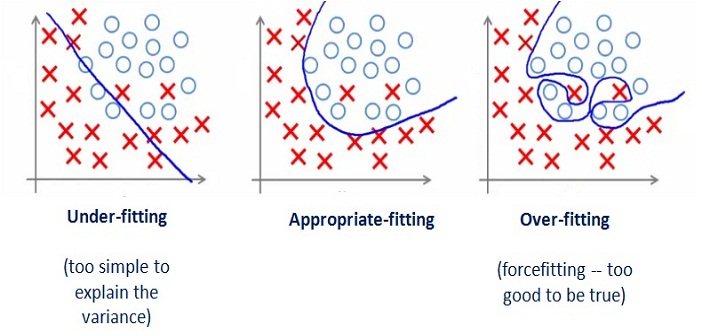

Now that we know what we want in terms of under-fitting and over-fitting, let’s talk about how to combat them.

How to combat over-fitting?

- Simplify the model by using less parameters.
- Simplify the model by changing the hyperparameters.
- Introducing regularization models.
- Use more training data.
- Gatter more data ( and gather better quality data).

#### This part of the kernel is a working progress. Please check back again for future updates.####

## 7b. K-Nearest Neighbor classifier(KNN)

```julia
## Importing the model.
from sklearn.neighbors import KNeighborsClassifier
## calling on the model oject.
knn = KNeighborsClassifier(metric='minkowski', p=2)
## knn classifier works by doing euclidian distance


## doing 10 fold staratified-shuffle-split cross validation
cv = StratifiedShuffleSplit(n_splits=10, test_size=.25, random_state=2)

accuracies = cross_val_score(knn, X,y, cv = cv, scoring='accuracy')
print ("Cross-Validation accuracy scores:{}".format(accuracies))
print ("Mean Cross-Validation accuracy score: {}".format(round(accuracies.mean(),3)))
```

[output not shown]

#### Manually find the best possible k value for KNN

```julia
## Search for an optimal value of k for KNN.
k_range = range(1,31)
k_scores = []
for k in k_range:
    knn = KNeighborsClassifier(n_neighbors=k)
    scores = cross_val_score(knn, X,y, cv = cv, scoring = 'accuracy')
    k_scores.append(scores.mean())
print("Accuracy scores are: {}\n".format(k_scores))
print ("Mean accuracy score: {}".format(np.mean(k_scores)))
```

[output not shown]

```julia
from matplotlib import pyplot as plt
plt.plot(k_range, k_scores)
```

[output not shown]

### Grid search on KNN classifier

```julia
from sklearn.model_selection import GridSearchCV
## trying out multiple values for k
k_range = range(1,31)
##
weights_options=['uniform','distance']
#
param = {'n_neighbors':k_range, 'weights':weights_options}
## Using startifiedShufflesplit.
cv = StratifiedShuffleSplit(n_splits=10, test_size=.30, random_state=15)
# estimator = knn, param_grid = param, n_jobs = -1 to instruct scikit learn to use all available processors.
grid = GridSearchCV(KNeighborsClassifier(), param,cv=cv,verbose = False, n_jobs=-1)
## Fitting the model.
grid.fit(X,y)
```

[output not shown]

```julia
print(grid.best_score_)
print(grid.best_params_)
print(grid.best_estimator_)
```

[output not shown]

#### Using best estimator from grid search using KNN.

```julia
### Using the best parameters from the grid-search.
knn_grid= grid.best_estimator_
knn_grid.score(X,y)
```

[output not shown]

#### Using RandomizedSearchCV

Randomized search is a close cousin of grid search. It doesn’t always provide the best result but its fast.

```julia
from sklearn.model_selection import RandomizedSearchCV
## trying out multiple values for k
k_range = range(1,31)
##
weights_options=['uniform','distance']
#
param = {'n_neighbors':k_range, 'weights':weights_options}
## Using startifiedShufflesplit.
cv = StratifiedShuffleSplit(n_splits=10, test_size=.30)
# estimator = knn, param_grid = param, n_jobs = -1 to instruct scikit learn to use all available processors.
## for RandomizedSearchCV,
grid = RandomizedSearchCV(KNeighborsClassifier(), param,cv=cv,verbose = False, n_jobs=-1, n_iter=40)
## Fitting the model.
grid.fit(X,y)
```

[output not shown]

```julia
print (grid.best_score_)
print (grid.best_params_)
print(grid.best_estimator_)
```

[output not shown]

```julia
### Using the best parameters from the grid-search.
knn_ran_grid = grid.best_estimator_
knn_ran_grid.score(X,y)
```

[output not shown]

## Gaussian Naive Bayes

```julia
# Gaussian Naive Bayes
from sklearn.naive_bayes import GaussianNB
from sklearn.metrics import accuracy_score

gaussian = GaussianNB()
gaussian.fit(X, y)
y_pred = gaussian.predict(X_test)
gaussian_accy = round(accuracy_score(y_pred, y_test), 3)
print(gaussian_accy)
```

[output not shown]

## Support Vector Machines(SVM)

```julia
from sklearn.svm import SVC
Cs = [0.001, 0.01, 0.1, 1,1.5,2,2.5,3,4,5, 10] ## penalty parameter C for the error term.
gammas = [0.0001,0.001, 0.01, 0.1, 1]
param_grid = {'C': Cs, 'gamma' : gammas}
cv = StratifiedShuffleSplit(n_splits=10, test_size=.30, random_state=15)
grid_search = GridSearchCV(SVC(kernel = 'rbf', probability=True), param_grid, cv=cv) ## 'rbf' stands for gaussian kernel
grid_search.fit(X,y)
```

[output not shown]

```julia
print(grid_search.best_score_)
print(grid_search.best_params_)
print(grid_search.best_estimator_)
```

[output not shown]

```julia
# using the best found hyper paremeters to get the score.
svm_grid = grid_search.best_estimator_
svm_grid.score(X,y)
```

[output not shown]

## Decision Tree Classifier

Decision tree works by breaking down the dataset into small subsets. This breaking down process is done by asking questions about the features of the datasets. The idea is to unmix the labels by asking fewer questions necessary. As we ask questions, we are breaking down the dataset into more subsets. Once we have a subgroup with only the unique type of labels, we end the tree in that node. If you would like to get a detailed understanding of Decision tree classifier, please take a look at [this](https://www.kaggle.com/masumrumi/decision-tree-with-titanic-dataset) kernel.

```julia
from sklearn.tree import DecisionTreeClassifier
max_depth = range(1,30)
max_feature = [21,22,23,24,25,26,28,29,30,'auto']
criterion=["entropy", "gini"]

param = {'max_depth':max_depth,
         'max_features':max_feature,
         'criterion': criterion}
grid = GridSearchCV(DecisionTreeClassifier(),
                                param_grid = param,
                                 verbose=False,
                                 cv=StratifiedKFold(n_splits=20, random_state=15, shuffle=True),
                                n_jobs = -1)
grid.fit(X, y)
```

[output not shown]

```julia
print( grid.best_params_)
print (grid.best_score_)
print (grid.best_estimator_)
```

[output not shown]

```julia
dectree_grid = grid.best_estimator_
## using the best found hyper paremeters to get the score.
dectree_grid.score(X,y)
```

[output not shown]

#### Let’s look at the feature importance from decision tree grid.

```julia
## feature importance
feature_importances = pd.DataFrame(dectree_grid.feature_importances_,
                                   index = column_names,
                                    columns=['importance'])
feature_importances.sort_values(by='importance', ascending=False).head(10)
```

[output not shown]

## 7f. Random Forest Classifier

I admire working with decision trees because of the potential and basics they provide towards building a more complex model like Random Forest(RF). RF is an ensemble method (combination of many decision trees) which is where the “forest” part comes in. One crucial details about Random Forest is that while using a forest of decision trees, RF model **takes random subsets of the original dataset(bootstrapped)** and **random subsets of the variables(features/columns)**. Using this method, the RF model creates 100’s-1000’s(the amount can be menually determined) of a wide variety of decision trees. This variety makes the RF model more effective and accurate. We then run each test data point through all of these 100’s to 1000’s of decision trees or the RF model and take a vote on the output.

```julia
from sklearn.model_selection import GridSearchCV, StratifiedKFold, StratifiedShuffleSplit
from sklearn.ensemble import RandomForestClassifier
n_estimators = [140,145,150,155,160];
max_depth = range(1,10);
criterions = ['gini', 'entropy'];
cv = StratifiedShuffleSplit(n_splits=10, test_size=.30, random_state=15)


parameters = {'n_estimators':n_estimators,
              'max_depth':max_depth,
              'criterion': criterions

        }
grid = GridSearchCV(estimator=RandomForestClassifier(max_features='auto'),
                                 param_grid=parameters,
                                 cv=cv,
                                 n_jobs = -1)
grid.fit(X,y)
```

[output not shown]

```julia
print (grid.best_score_)
print (grid.best_params_)
print (grid.best_estimator_)
```

[output not shown]

```julia
rf_grid = grid.best_estimator_
rf_grid.score(X,y)
```

[output not shown]

```julia
from sklearn.metrics import classification_report
# Print classification report for y_test
print(classification_report(y_test, y_pred, labels=rf_grid.classes_))
```

[output not shown]

## Feature Importance

```julia
## feature importance
feature_importances = pd.DataFrame(rf_grid.feature_importances_,
                                   index = column_names,
                                    columns=['importance'])
feature_importances.sort_values(by='importance', ascending=False).head(10)
```

[output not shown]

## Introducing Ensemble Learning

In statistics and machine learning, ensemble methods use multiple learning algorithms to obtain better predictive performance than could be obtained from any of the constituent learning algorithms alone.

There are two types of ensemple learnings.

**Bagging/Averaging Methods**

> In averaging methods, the driving principle is to build several estimators independently and then to average their predictions. On average, the combined estimator is usually better than any of the single base estimator because its variance is reduced.

**Boosting Methods**

> The other family of ensemble methods are boosting methods, where base estimators are built sequentially and one tries to reduce the bias of the combined estimator. The motivation is to combine several weak models to produce a powerful ensemble.

#### Source:GA

Resource: [Ensemble methods: bagging, boosting and stacking](https://towardsdatascience.com/ensemble-methods-bagging-boosting-and-stacking-c9214a10a205)

## 7g. Bagging Classifier

[Bagging Classifier](https://scikit-learn.org/stable/modules/generated/sklearn.ensemble.BaggingClassifier.html)(Bootstrap Aggregating) is the ensemble method that involves manipulating the training set by resampling and running algorithms on it. Let’s do a quick review:

- Bagging classifier uses a process called bootstrapped dataset to create multiple datasets from one original dataset and runs algorithm on each one of them. Here is an image to show how bootstrapped dataset works.

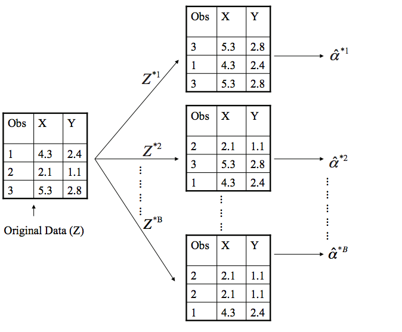

#### Resampling from original dataset to bootstrapped datasets

#### Source: https://uc-r.github.io

- After running a learning algorithm on each one of the bootstrapped datasets, all models are combined by taking their average. the test data/new data then go through this averaged classifier/combined classifier and predict the output.

Here is an image to make it clear on how bagging works,

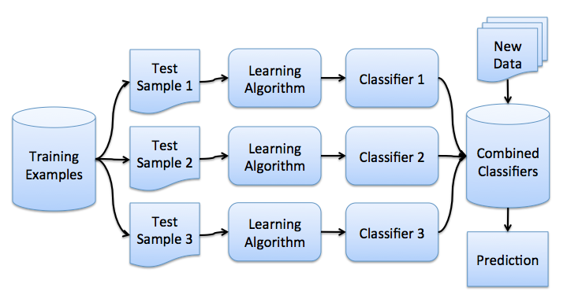

#### Source: https://prachimjoshi.files.wordpress.com

Please check out [this](https://www.kaggle.com/masumrumi/bagging-with-titanic-dataset) kernel if you want to find out more about bagging classifier.

```julia
from sklearn.ensemble import BaggingClassifier
n_estimators = [10,30,50,70,80,150,160, 170,175,180,185];
cv = StratifiedShuffleSplit(n_splits=10, test_size=.30, random_state=15)

parameters = {'n_estimators':n_estimators,

        }
grid = GridSearchCV(BaggingClassifier(base_estimator= None, ## If None, then the base estimator is a decision tree.
                                      bootstrap_features=False),
                                 param_grid=parameters,
                                 cv=cv,
                                 n_jobs = -1)
grid.fit(X,y)
```

[output not shown]

```julia
print (grid.best_score_)
print (grid.best_params_)
print (grid.best_estimator_)
```

[output not shown]

```julia
bagging_grid = grid.best_estimator_
bagging_grid.score(X,y)
```

[output not shown]

### Why use Bagging? (Pros and cons)

Bagging works best with strong and complex models(for example, fully developed decision trees). However, don’t let that fool you to thinking that similar to a decision tree, bagging also overfits the model. Instead, bagging reduces overfitting since a lot of the sample training data are repeated and used to create base estimators. With a lot of equally likely training data, bagging is not very susceptible to overfitting with noisy data, therefore reduces variance. However, the downside is that this leads to an increase in bias.

#### Random Forest VS. Bagging Classifier

If some of you are like me, you may find Random Forest to be similar to Bagging Classifier. However, there is a fundamental difference between these two which is **Random Forests ability to pick subsets of features in each node.** I will elaborate on this in a future update.

## 7h. AdaBoost Classifier

AdaBoost is another **ensemble model** and is quite different than Bagging. Let’s point out the core concepts.

> AdaBoost combines a lot of “weak learners”(they are also called stump; a tree with only one node and two leaves) to make classifications.

> This base model fitting is an iterative process where each stump is chained one after the other; **It cannot run in parallel.**

> **Some stumps get more say in the final classifications than others.** The models use weights that are assigned to each data point/raw indicating their “importance.” Samples with higher weight have a higher influence on the total error of the next model and gets more priority. The first stump starts with uniformly distributed weight which means, in the beginning, every datapoint have an equal amount of weights.

> **Each stump is made by talking the previous stump’s mistakes into account.** After each iteration weights gets re-calculated in order to take the errors/misclassifications from the last stump into consideration.

> The final prediction is typically constructed by a weighted vote where weights for each base model depends on their training errors or misclassification rates.

To illustrate what we have talked about so far let’s look at the following visualization.

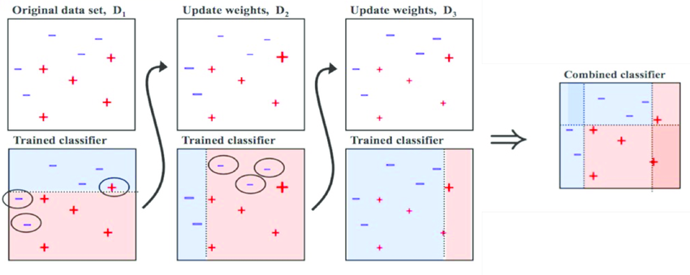

##### Source: Diogo(Medium)

Let’s dive into each one of the nitty-gritty stuff about AdaBoost:

> **First**, we determine the best feature to split the dataset using Gini index(basics from decision tree). The feature with the lowest Gini index becomes the first stump in the AdaBoost stump chain(the lower the Gini index is, the better unmixed the label is, therefore, better split).

> **Secondly**, we need to determine how much say a stump will have in the final classification and how we can calculate that.
- We learn how much say a stump has in the final classification by calculating how well it classified the samples (aka calculate the total error of the weight).
- The **Total Error** for a stump is the sum of the weights associated with the incorrectly classified samples. For example, lets say, we start a stump with 10 datasets. The first stump will uniformly distribute an weight amoung all the datapoints. Which means each data point will have 1/10 weight. Let’s say once the weight is distributed we run the model and find 2 incorrect predicitons. In order to calculate the total erorr we add up all the misclassified weights. Here we get 1/10 + 1/10 = 2/10 or 1/5. This is our total error. We can also think about it

$$\epsilon_t = \frac{\text{misclassifications}\_t}{\text{observations}\_t}$$

- Since the weight is uniformly distributed(all add up to 1) among all data points, the total error will always be between 0(perfect stump) and 1(horrible stump).
- We use the total error to determine the amount of say a stump has in the final classification using the following formula

$$\alpha_t = \frac{1}{2}ln \left(\frac{1-\epsilon_t}{\epsilon_t}\right) \text{where } \epsilon_t < 1$$

Where $\epsilon_t$ is the misclassification rate for the current classifier:

$$\epsilon_t = \frac{\text{misclassifications}\_t}{\text{observations}\_t}$$

Here…

- $\alpha_t$ = Amount of Say
- $\epsilon_t$ = Total error

We can draw a graph to determine the amount of say using the value of total error(0 to 1)

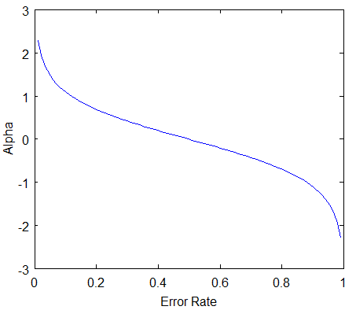

##### Source: Chris McCormick

- The blue line tells us the amount of say for **Total Error(Error rate)** between 0 and 1.
- When the stump does a reasonably good job, and the **total error** is minimal, then the **amount of say(Alpha)** is relatively large, and the alpha value is positive.
- When the stump does an average job(similar to a coin flip/the ratio of getting correct and incorrect ~50%/50%), then the **total error** is ~0.5. In this case the **amount of say** is **0**.
- When the error rate is high let’s say close to 1, then the **amount of say** will be negative, which means if the stump outputs a value as “survived” the included weight will turn that value into “not survived.”

P.S. If the **Total Error** is 1 or 0, then this equation will freak out. A small amount of error is added to prevent this from happening.

> **Third**, We need to learn how to modify the weights so that the next stump will take the errors that the current stump made into account. The pseducode for calculating the new sample weight is as follows.

Here the $\alpha_t(AmountOfSay)$ can be positive or negative depending whether the sample was correctly classified or misclassified by the current stump. We want to increase the sample weight of the misclassified samples; hinting the next stump to put more emphasize on those. Inversely, we want to decrease the sample weight of the correctly classified samples; hinting the next stump to put less emphasize on those.

The following equation help us to do this calculation.

$$D\_{t+1}(i) = D_t(i) e^{-\alpha_t y_i h_t(x_i)}$$

Here,

- $D_{t+1}(i)$ = New Sample Weight.
- $D_t(i)$ = Current Sample weight.
- $\alpha_t$ = Amount of Say, alpha value, this is the coefficient that gets updated in each iteration and
- $y_i h_t(x_i)$ = place holder for 1 if stump correctly classified, -1 if misclassified.

Finally, we put together the combined classifier, which is

$$AdaBoost(X) = sign\left(\sum\_{t=1}^T\alpha_t h_t(X)\right)$$

Here,

$AdaBoost(X)$ is the classification predictions for $y$ using predictor matrix $X$

$T$ is the set of “weak learners”

$\alpha_t$ is the contribution weight for weak learner $t$

$h_t(X)$ is the prediction of weak learner $t$

and $y$ is binary **with values -1 and 1**

P.S. Since the stump barely captures essential specs about the dataset, the model is highly biased in the beginning. However, as the chain of stumps continues and at the end of the process, AdaBoost becomes a strong tree and reduces both bias and variance.

### Resources:

- [Statquest](https://www.youtube.com/watch?v=LsK-xG1cLYA)
- [Principles of Machine Learning | AdaBoost(Video)](https://www.youtube.com/watch?v=-DUxtdeCiB4)

```julia
from sklearn.ensemble import AdaBoostClassifier
n_estimators = [100,140,145,150,160, 170,175,180,185];
cv = StratifiedShuffleSplit(n_splits=10, test_size=.30, random_state=15)
learning_r = [0.1,1,0.01,0.5]

parameters = {'n_estimators':n_estimators,
              'learning_rate':learning_r

        }
grid = GridSearchCV(AdaBoostClassifier(base_estimator= None, ## If None, then the base estimator is a decision tree.
                                     ),
                                 param_grid=parameters,
                                 cv=cv,
                                 n_jobs = -1)
grid.fit(X,y)
```

[output not shown]

```julia
print (grid.best_score_)
print (grid.best_params_)
print (grid.best_estimator_)
```

[output not shown]

```julia
adaBoost_grid = grid.best_estimator_
adaBoost_grid.score(X,y)
```

[output not shown]

## Pros and cons of boosting

### Pros

- Achieves higher performance than bagging when hyper-parameters tuned properly.
- Can be used for classification and regression equally well.
- Easily handles mixed data types.
- Can use “robust” loss functions that make the model resistant to outliers.

### Cons

- Difficult and time consuming to properly tune hyper-parameters.
- Cannot be parallelized like bagging (bad scalability when huge amounts of data).
- More risk of overfitting compared to bagging.

### Resources:

- [AdaBoost Tutorial-Chris McCormick](http://mccormickml.com/2013/12/13/adaboost-tutorial/)
- [Explaining AdaBoost by Robert Schapire(One of the original author of AdaBoost)](http://rob.schapire.net/papers/explaining-adaboost.pdf)

## 7i. Gradient Boosting Classifier

```julia
# Gradient Boosting Classifier
from sklearn.ensemble import GradientBoostingClassifier

gradient_boost = GradientBoostingClassifier()
gradient_boost.fit(X, y)
y_pred = gradient_boost.predict(X_test)
gradient_accy = round(accuracy_score(y_pred, y_test), 3)
print(gradient_accy)
```

[output not shown]

### Resources:

- [Gradient Descent(StatQuest)](https://www.youtube.com/watch?v=sDv4f4s2SB8)
- [Gradient Boost(Regression Main Ideas)(StatQuest)](https://www.youtube.com/watch?v=3CC4N4z3GJc)
- [Gradient Boost(Regression Calculation)(StatQuest)](https://www.youtube.com/watch?v=3CC4N4z3GJc)
- [Gradient Boost(Classification Main Ideas)(StatQuest)](https://www.youtube.com/watch?v=jxuNLH5dXCs)
- [Gradient Boost(Classification Calculation)(StatQuest)](https://www.youtube.com/watch?v=StWY5QWMXCw)
- [Complete Machine Learning Guide to Parameter Tuning in Gradient Boosting (GBM) in Python](https://www.analyticsvidhya.com/blog/2016/02/complete-guide-parameter-tuning-gradient-boosting-gbm-python/)

## 7j. XGBClassifier

```julia
# from xgboost import XGBClassifier
# XGBClassifier = XGBClassifier()
# XGBClassifier.fit(X, y)
# y_pred = XGBClassifier.predict(X_test)
# XGBClassifier_accy = round(accuracy_score(y_pred, y_test), 3)
# print(XGBClassifier_accy)
```

## 7k. Extra Trees Classifier

```julia
from sklearn.ensemble import ExtraTreesClassifier
ExtraTreesClassifier = ExtraTreesClassifier()
ExtraTreesClassifier.fit(X, y)
y_pred = ExtraTreesClassifier.predict(X_test)
extraTree_accy = round(accuracy_score(y_pred, y_test), 3)
print(extraTree_accy)
```

[output not shown]

## 7l. Gaussian Process Classifier

```julia
from sklearn.gaussian_process import GaussianProcessClassifier
GaussianProcessClassifier = GaussianProcessClassifier()
GaussianProcessClassifier.fit(X, y)
y_pred = GaussianProcessClassifier.predict(X_test)
gau_pro_accy = round(accuracy_score(y_pred, y_test), 3)
print(gau_pro_accy)
```

[output not shown]

## 7m. Voting Classifier

```julia
from sklearn.ensemble import VotingClassifier

voting_classifier = VotingClassifier(estimators=[
    ('lr_grid', logreg_grid),
    ('svc', svm_grid),
    ('random_forest', rf_grid),
    ('gradient_boosting', gradient_boost),
    ('decision_tree_grid',dectree_grid),
    ('knn_classifier', knn_grid),
#     ('XGB_Classifier', XGBClassifier),
    ('bagging_classifier', bagging_grid),
    ('adaBoost_classifier',adaBoost_grid),
    ('ExtraTrees_Classifier', ExtraTreesClassifier),
    ('gaussian_classifier',gaussian),
    ('gaussian_process_classifier', GaussianProcessClassifier)
],voting='hard')

#voting_classifier = voting_classifier.fit(train_x,train_y)
voting_classifier = voting_classifier.fit(X,y)
```

[output not shown]

```julia
y_pred = voting_classifier.predict(X_test)
voting_accy = round(accuracy_score(y_pred, y_test), 3)
print(voting_accy)
```

[output not shown]

```julia
#models = pd.DataFrame({
#    'Model': ['Support Vector Machines', 'KNN', 'Logistic Regression',
#              'Random Forest', 'Naive Bayes',
#              'Decision Tree', 'Gradient Boosting Classifier', 'Voting Classifier', 'XGB Classifier','ExtraTrees Classifier','Bagging Classifier'],
#    'Score': [svc_accy, knn_accy, logreg_accy,
#              random_accy, gaussian_accy, dectree_accy,
#               gradient_accy, voting_accy, XGBClassifier_accy, extraTree_accy, bagging_accy]})
#models.sort_values(by='Score', ascending=False)
```

# Part 8: Submit test predictions

```julia
all_models = [logreg_grid,
              knn_grid,
              knn_ran_grid,
              svm_grid,
              dectree_grid,
              rf_grid,
              bagging_grid,
              adaBoost_grid,
              voting_classifier]

c = {}
for i in all_models:
    a = i.predict(X_test)
    b = accuracy_score(a, y_test)
    c[i] = b
```

[output not shown]

```julia
test_prediction = (max(c, key=c.get)).predict(test)
submission = pd.DataFrame({
        "PassengerId": passengerid,
        "Survived": test_prediction
    })

submission.PassengerId = submission.PassengerId.astype(int)
submission.Survived = submission.Survived.astype(int)

submission.to_csv("titanic1_submission.csv", index=False)
```

[output not shown]

[output not shown]

#### If you like to discuss any other projects or just have a chat about data science topics, I’ll be more than happy to connect with you on:

[output not shown]

This kernel will always be a work in progress. I will incorporate new concepts of data science as I comprehend them with each update. If you have any idea/suggestions about this notebook, please let me know. Any feedback about further improvements would be genuinely appreciated.

# If you have come this far, Congratulations!!

# If this notebook helped you in any way or you liked it, please upvote and/or leave a comment!! :)